# US House Build Time Series Analysis

## Background

The Federal Reserve Bank of St. Louis’s [FRED website](https://fred.stlouisfed.org) provides a wide range of public economic data, including unemployment rates, house prices and inflation. Using these indicators to forecast other economic measures is a longstanding challenge. In this notebook, we explore whether historical economic data can help predict housing starts over the next year.

Economic forecasting is notoriously difficult. We will build relatively simple models using a small number of indicators, without explicitly incorporating international events, policy changes or broader global economic conditions.

We do not expect perfectly accurate forecasts. Instead, we aim to assess whether these models can identify broad trends and provide insight into the relationships between housing construction and other aspects of the economy.

## Environment Setup

First, we install the libraries needed to retrieve and analyse the data.

```python
import gzip
import io
from pathlib import Path
from urllib.request import urlopen
import numpy as np

import pandas as pd
import matplotlib.pyplot as plt
from matplotlib.backends.backend_pdf import PdfPages

from sklearn.pipeline import make_pipeline
from sklearn.preprocessing import StandardScaler
from sklearn.ensemble import RandomForestRegressor
from sklearn.linear_model import LinearRegression, Ridge
```

## Data Loading

We load economic data from FRED for January 2000 to December 2025. We aim to forecast housing starts using their historical values alongside building permits, new home sales, the house price index, mortgage rates, unemployment, the federal funds rate, CPI and new home months’ supply.

Some definitions:

- **New Home Months’ Supply:** The number of months it would take to sell the current inventory of new homes at the current sales pace.
- **Federal Funds Rate:** The interest rate at which US banks lend reserve balances to each other overnight.
- **Mortgage Rate:** The interest rate charged on a loan to buy a property. We use the average 30-year fixed mortgage rate.
- **Consumer Price Index (CPI):** An index measuring the prices of a basket of consumer goods and services, including food, housing, transport and healthcare. Changes in CPI are used to measure inflation.

We loop through each data URL and check whether the series needs to be converted to monthly frequency. Mortgage rates are reported weekly, and need to be converted, while the other selected series are reported monthly.

```python
START = "2000-01-01"
END = "2025-12-31"

SERIES = {
    "Housing Starts": "HOUST",
    "Building Permits": "PERMIT",
    "New Home Sales": "HSN1F",
    "New Home Months Supply": "MSACSR",
    "House Price Index": "CSUSHPISA",
    "Mortgage Rate": "MORTGAGE30US",
    "Unemployment": "UNRATE",
    "Fed Funds Rate": "FEDFUNDS",
    "Inflation CPI": "CPIAUCSL",
}

columns = []

for name, code in SERIES.items():
    url = (
        f"https://fred.stlouisfed.org/graph/fredgraph.csv"
        f"?id={code}&cosd={START}&coed={END}"
    )

    with urlopen(url, timeout=60) as response:
        raw = response.read()

    frame = pd.read_csv(io.BytesIO(raw), na_values=["."])

    series = pd.Series(
        pd.to_numeric(frame[code], errors="coerce").to_numpy(),
        index=pd.to_datetime(frame.iloc[:, 0]),
        name=name,
    )

    # Monthly averages; weekly mortgage rates become one value per month.
    columns.append(series.resample("MS").mean())

df = pd.concat(columns, axis=1).reindex(
    pd.date_range(START, END, freq="MS")
)
df.index.name = "Month"
```

We inspect the first few rows of the dataset to check its structure and confirm that all data columns contain numeric values.

```python
# Missing observations remain NaN.
df.head()
```

| Month | Housing Starts | Building Permits | New Home Sales | New Home Months Supply | House Price Index | Mortgage Rate | Unemployment | Fed Funds Rate | Inflation CPI |
| --- | --- | --- | --- | --- | --- | --- | --- | --- | --- |
| 2000-01-01 | 1636.0 | 1727.0 | 873.0 | 4.3 | 100.551 | 8.2100 | 4.0 | 5.45 | 169.3 |
| 2000-02-01 | 1737.0 | 1692.0 | 856.0 | 4.3 | 101.339 | 8.3250 | 4.1 | 5.73 | 170.0 |
| 2000-03-01 | 1604.0 | 1651.0 | 900.0 | 4.3 | 102.127 | 8.2400 | 4.0 | 5.85 | 171.0 |
| 2000-04-01 | 1626.0 | 1597.0 | 841.0 | 4.4 | 102.923 | 8.1525 | 3.8 | 6.02 | 170.9 |
| 2000-05-01 | 1575.0 | 1543.0 | 857.0 | 4.4 | 103.678 | 8.5150 | 4.0 | 6.27 | 171.2 |

## Data Exploration

We check the dataset for missing values.

```python
# Count missing values in each column.
missing_summary = pd.DataFrame({
    "Missing values": df.isna().sum(),
    "Missing (%)": df.isna().mean().mul(100).round(1),
})

display(missing_summary)

# Show rows containing any missing values.
missing_rows = df.loc[df.isna().any(axis=1)]

print(f"Rows with missing values: {len(missing_rows)} of {len(df)}")
display(missing_rows)

# Check for missing months in the date index.
expected_months = pd.date_range(df.index.min(), df.index.max(), freq="MS")
missing_months = expected_months.difference(df.index)

print("Missing months:", missing_months.tolist())
```

|  | Missing values | Missing (%) |
| --- | --- | --- |
| Housing Starts | 0 | 0.0 |
| Building Permits | 0 | 0.0 |
| New Home Sales | 0 | 0.0 |
| New Home Months Supply | 0 | 0.0 |
| House Price Index | 0 | 0.0 |
| Mortgage Rate | 0 | 0.0 |
| Unemployment | 1 | 0.3 |
| Fed Funds Rate | 0 | 0.0 |
| Inflation CPI | 1 | 0.3 |

```
Rows with missing values: 1 of 312
```

| Month | Housing Starts | Building Permits | New Home Sales | New Home Months Supply | House Price Index | Mortgage Rate | Unemployment | Fed Funds Rate | Inflation CPI |
| --- | --- | --- | --- | --- | --- | --- | --- | --- | --- |
| 2025-10-01 | 1273.0 | 1418.0 | 652.0 | 9.0 | 328.837 | 6.254 | NaN | 4.09 | NaN |

```
Missing months: []
```

No months are entirely missing from the dataset. However, two values are missing for October 2025. We fill each gap with the average of its September and November values.

```python
# Fill isolated missing values with the average of their two neighbours.
previous = df.shift(1)
following = df.shift(-1)

fillable = df.isna() & previous.notna() & following.notna()
df = df.mask(fillable, (previous + following) / 2)

display(df.isna().sum().rename("Remaining missing values"))
```

```
Housing Starts            0
Building Permits          0
New Home Sales            0
New Home Months Supply    0
House Price Index         0
Mortgage Rate             0
Unemployment              0
Fed Funds Rate            0
Inflation CPI             0
Name: Remaining missing values, dtype: int64
```

With the missing values filled, we plot housing starts alongside the other economic indicators. Because the series have different scales, we rebase each one to start at 1 so we can compare their proportional changes. We also apply a six-month moving average to smooth short-term fluctuations.

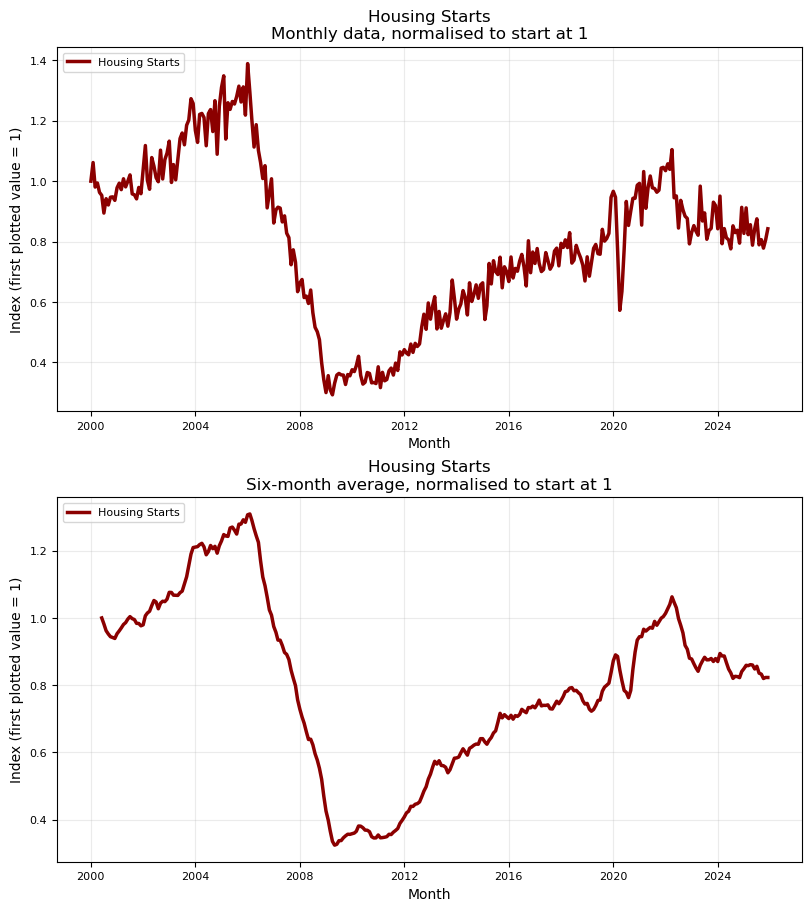

```python
# Housing Starts only: monthly data and six-month trailing average.
starts = df["Housing Starts"]
smoothed = starts.rolling(window=6, min_periods=6).mean().iloc[5:]

datasets = [
    ("Monthly data", starts.div(starts.iloc[0])),
    ("Six-month average", smoothed.div(smoothed.iloc[0])),
]

fig, axes = plt.subplots(
    2, 1,
    figsize=(8, 9),
    constrained_layout=True,
    sharex=True,
)

for ax, (description, normalised) in zip(axes, datasets):
    ax.plot(
        normalised.index,
        normalised,
        label="Housing Starts",
        color="#8B0000",
        linewidth=2.5,
    )

    ax.set(
        title=f"Housing Starts\n{description}, normalised to start at 1",
        xlabel="Month",
        ylabel="Index (first plotted value = 1)",
    )
    ax.legend(loc="upper left", fontsize=8)
    ax.set_axisbelow(True)
    ax.grid(alpha=0.25)
    ax.tick_params(axis="both", labelsize=8, labelbottom=True)

plt.show()
```

Two major events stand out: the 2008 financial crisis and the onset of the COVID-19 pandemic in early 2020, followed by a recovery. No clear recurring cycle or seasonal pattern is apparent in these plots, although further analysis may reveal patterns that are less visible here.

Next, we compare housing starts with the other economic indicators, with each series rebased to start at 1.

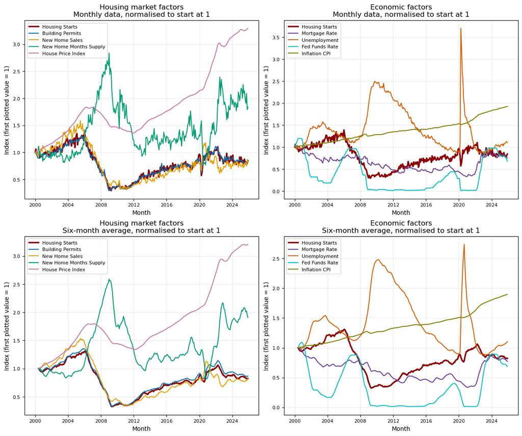

```python
groups = {
    "Housing market factors": {
        "Building Permits": "#0072B2",
        "New Home Sales": "#E69F00",
        "New Home Months Supply": "#009E73",
        "House Price Index": "#CC79A7",
    },
    "Economic factors": {
        "Mortgage Rate": "#6A3D9A",
        "Unemployment": "#D95F02",
        "Fed Funds Rate": "#00BFC4",
        "Inflation CPI": "#808000",
    },
}

# Original data and six-month trailing averages.
smoothed = df.rolling(window=6, min_periods=6).mean().iloc[5:]

datasets = [
    ("Monthly data", df.div(df.iloc[0])),
    ("Six-month average", smoothed.div(smoothed.iloc[0])),
]

fig, axes = plt.subplots(
    2, 2,
    figsize=(12, 10),
    constrained_layout=True,
    sharex=True,
)

for row, (description, normalised) in enumerate(datasets):
    for col, (title, factors) in enumerate(groups.items()):
        ax = axes[row, col]

        ax.plot(
            normalised.index,
            normalised["Housing Starts"],
            label="Housing Starts",
            color="#8B0000",
            linewidth=2.5,
            zorder=2,
        )

        for factor, colour in factors.items():
            ax.plot(
                normalised.index,
                normalised[factor],
                label=factor,
                color=colour,
                linewidth=1.5,
                zorder=3,
            )

        ax.set(
            title=f"{title}\n{description}, normalised to start at 1",
            xlabel="Month",
            ylabel="Index (first plotted value = 1)",
        )
        ax.legend(loc="upper left", fontsize=8)
        ax.set_axisbelow(True)
        ax.grid(alpha=0.25)
        ax.tick_params(axis="both", labelsize=8, labelbottom=True)

plt.show()
```

Visually, several indicators appear to move with housing starts, while others move in the opposite direction. Building permits and new home sales appear to follow similar patterns to housing starts. The house price index, new home months’ supply and unemployment appear to move in the opposite direction during parts of the period. Mortgage rates and CPI show less obvious relationships.

Some indicators appear to respond after changes in housing starts. This suggests that housing starts may lead certain economic indicators, although visual inspection alone cannot establish predictive relationships.

```python
CUTOFF = "2020-12-01"

training = df.loc[df.index <= pd.Timestamp(CUTOFF)].copy()
actual = df.loc[df.index > pd.Timestamp(CUTOFF)].iloc[:36].copy()
```

We calculate Pearson correlations between each indicator and housing starts at different monthly delays, using both the original values and year-on-year percentage changes. Each year-on-year change compares a month’s value with its value 12 months earlier.

Positive delays compare an indicator this month with housing starts in a future month. Negative delays compare it with housing starts in an earlier month, helping us explore whether housing starts may lead other indicators.

We also include housing starts itself to examine its autocorrelation at different delays. All correlations are calculated using training data only.

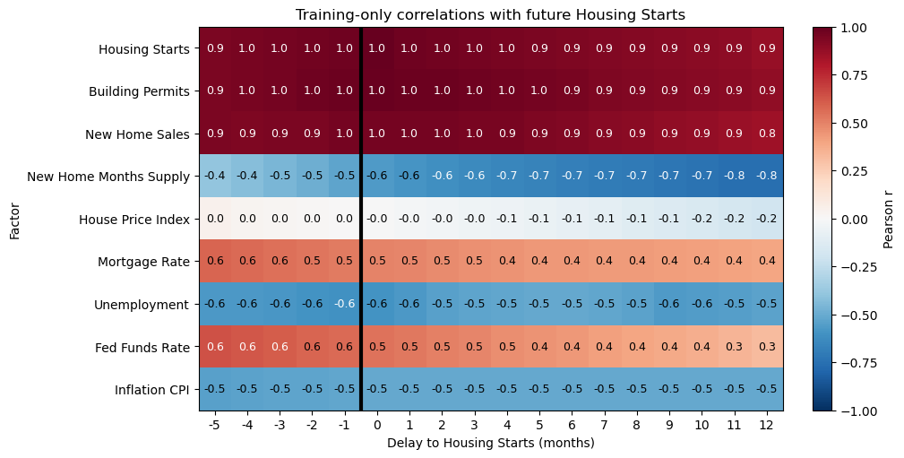

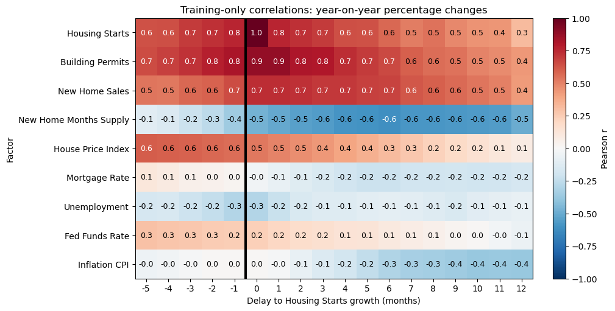

```python
def plot_correlations(data, title, xlabel, target="Housing Starts"):
    factors = data.columns
    delays = range(-5, 13)

    correlations = pd.DataFrame(
        {
            delay: data[factors].corrwith(data[target].shift(-delay))
            for delay in delays
        }
    )

    fig, ax = plt.subplots(figsize=(10, 5), constrained_layout=True)

    heatmap = ax.imshow(
        correlations.to_numpy(),
        cmap="RdBu_r",
        vmin=-1,
        vmax=1,
        aspect="auto",
    )

    ax.set_xticks(range(len(delays)))
    ax.set_xticklabels(list(delays))
    ax.set_yticks(range(len(factors)))
    ax.set_yticklabels(factors)

    for row in range(len(factors)):
        for col in range(len(delays)):
            value = correlations.iloc[row, col]
            if np.isfinite(value):
                ax.text(
                    col,
                    row,
                    f"{value:.1f}",
                    ha="center",
                    va="center",
                    fontsize=9,
                    color="white" if abs(value) >= 0.6 else "black",
                )

    zero_position = list(delays).index(0)
    ax.axvline(zero_position - 0.5, color="black", linewidth=3)

    ax.set(title=title, xlabel=xlabel, ylabel="Factor")
    fig.colorbar(heatmap, ax=ax, label="Pearson r")
    plt.show()

    return correlations


# Original training data.
level_correlations = plot_correlations(
    training,
    title="Training-only correlations with future Housing Starts",
    xlabel="Delay to Housing Starts (months)",
)

# Year-on-year percentage changes using training data only.
changes = training.pct_change(periods=12, fill_method=None).mul(100)

growth_correlations = plot_correlations(
    changes,
    title="Training-only correlations: year-on-year percentage changes",
    xlabel="Delay to Housing Starts growth (months)",
)
```

Year-on-year correlations are generally weaker than correlations between the original values. This suggests that shared trends and persistence may account for some of the stronger relationships in the original data.

Housing starts also shows strong autocorrelation, meaning its current value is closely related to its future values. A naïve forecast that repeats the last observed value may therefore provide a useful baseline. Predicting the general level of housing starts may be easier than predicting changes in direction.

Building permits and new home sales may reflect the same economic cycle as housing starts, so their information could overlap. However, we should compare model performance with and without these indicators before deciding whether to exclude them.

## Training the Models

We create lagged inputs for each indicator, using the current month and the previous 11 months. We then train a separate model for each of the next 36 months. This direct forecasting approach predicts each future month independently, without using predictions from other forecast horizons as inputs.

We compare the following approaches:

- **Last-value baseline:** Repeats the most recent observed housing starts value.
- **Ridge regression using all factors:** Uses current and historical values of housing starts and the other selected indicators.
- **Ridge regression using housing starts only plus selected factors:** Uses current and historical housing starts and some hand picked selected factors.
- **Random forest using all factors:** Uses the same inputs as the all-factor Ridge model.

```python
HORIZON = 36
TARGET = "Housing Starts"

FULL_LAGS = list(range(12))
REDUCED_LAGS = [0, 1, 3, 6, 11]

train = training.sort_index().copy()

# Fill isolated gaps using training values only.
previous = train.shift(1)
following = train.shift(-1)
fillable = train.isna() & previous.notna() & following.notna()
train = train.mask(fillable, (previous + following) / 2)

expected_dates = pd.date_range(
    train.index.min(), train.index.max(), freq="MS"
)

if train.index.has_duplicates or not train.index.equals(expected_dates):
    raise ValueError(
        "Training data must have a unique, continuous monthly index."
    )


def make_features(frame, columns, lag_offsets):
    return pd.concat(
        {
            f"{column}_lag_{lag}": frame[column].shift(lag)
            for column in columns
            for lag in lag_offsets
        },
        axis=1,
    )


def ridge_model():
    return make_pipeline(StandardScaler(), Ridge(alpha=100.0))


def forest_model():
    return RandomForestRegressor(
        n_estimators=200,
        min_samples_leaf=5,
        max_features=0.7,
        random_state=42,
        n_jobs=-1,
    )


def fit_direct_models(features, model_factory):
    origin = features.iloc[[-1]]

    if origin.isna().any().any():
        raise ValueError("Missing values in forecast-origin inputs.")

    fitted_models = {}
    forecasts = []

    # Each model uses only targets observed within training.
    for horizon in range(1, HORIZON + 1):
        target = train[TARGET].shift(-horizon)
        valid = features.notna().all(axis=1) & target.notna()

        if valid.sum() < 24:
            raise ValueError(
                f"Too few training examples for month {horizon}."
            )

        model = model_factory()
        model.fit(features.loc[valid], target.loc[valid])

        fitted_models[horizon] = model
        forecasts.append(model.predict(origin)[0])

    return fitted_models, np.maximum(forecasts, 0)


# Selected factors and lags for each model.
specifications = {
    "Ridge: starts only": (
        [TARGET], FULL_LAGS, ridge_model
    ),
    "Ridge: all factors": (
        list(train.columns), FULL_LAGS, ridge_model
    ),
    "Random forest: all factors": (
        list(train.columns), FULL_LAGS, forest_model
    ),
    "Ridge: reduced starts only": (
        [TARGET], REDUCED_LAGS, ridge_model
    ),
    "Ridge: starts + permits": (
        [TARGET, "Building Permits"], REDUCED_LAGS, ridge_model
    ),
    "Ridge: starts + sales": (
        [TARGET, "New Home Sales"], REDUCED_LAGS, ridge_model
    ),
    "Ridge: starts + supply": (
        [TARGET, "New Home Months Supply"], REDUCED_LAGS, ridge_model
    ),
}

last_value = train[TARGET].iloc[-1]

if pd.isna(last_value):
    raise ValueError("The final training Housing Starts value is missing.")

forecast_dates = pd.date_range(
    train.index[-1] + pd.offsets.MonthBegin(1),
    periods=HORIZON,
    freq="MS",
)

models = {"Last-value baseline": last_value}
feature_sets = {}

predictions = pd.DataFrame(
    {"Last-value baseline": np.repeat(last_value, HORIZON)},
    index=forecast_dates,
)
predictions.index.name = "Month"

for name, (columns, lag_offsets, model_factory) in specifications.items():
    features = make_features(train, columns, lag_offsets)
    feature_sets[name] = features

    models[name], forecasts = fit_direct_models(features, model_factory)
    predictions[name] = forecasts

# Keep these names available for your existing importance-analysis cell.
starts_features = feature_sets["Ridge: starts only"]
factor_features = feature_sets["Ridge: all factors"]
```

## Reviewing the Models

However, these forecasts do not appear substantially better than the last-value baseline, as housing starts remain relatively stable over the test period. We compare their error metrics next to assess whether they improve on the baseline.

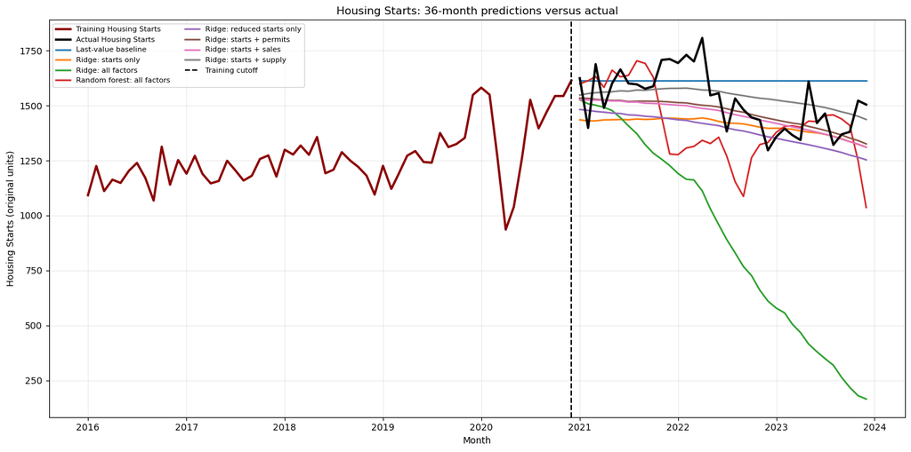

```python
fig, ax = plt.subplots(figsize=(14, 7))

# Show the last five years of training data.
ax.plot(
    train[TARGET].iloc[-60:],
    color="#8B0000",
    linewidth=2.5,
    label="Training Housing Starts",
)

ax.plot(
    actual[TARGET].reindex(predictions.index),
    color="black",
    linewidth=2.5,
    label="Actual Housing Starts",
    zorder=5,
)

# One colour per model, including all new models.
palette = plt.get_cmap("tab10")

for number, (name, forecast) in enumerate(predictions.items()):
    ax.plot(
        forecast.index,
        forecast,
        label=name,
        color=palette(number % 10),
        linewidth=1.8,
    )

ax.axvline(
    train.index[-1],
    color="black",
    linestyle="--",
    label="Training cutoff",
)

ax.set(
    title="Housing Starts: 36-month predictions versus actual",
    xlabel="Month",
    ylabel="Housing Starts (original units)",
)
ax.legend(loc="upper left", fontsize=8, ncol=2)
ax.set_axisbelow(True)
ax.grid(alpha=0.25)
fig.tight_layout()
plt.show()
```

We examine the relative importance of each factor in the fitted models to understand which inputs they rely on most. These measures describe model behaviour, rather than causal effects or guaranteed contributions to forecast accuracy.

```
Ridge: starts only: average importance across horizons (%)
Housing Starts    100.0
```

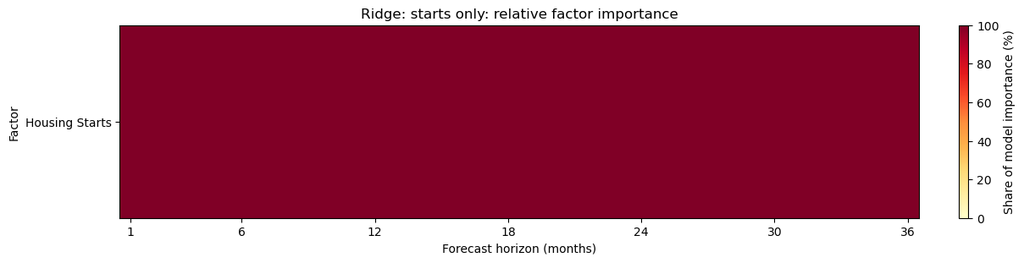

```
Ridge: all factors: average importance across horizons (%)
New Home Months Supply    16.8
Fed Funds Rate            16.6
Unemployment              16.0
House Price Index         10.9
Mortgage Rate             10.2
New Home Sales            10.1
Building Permits           8.4
Housing Starts             7.6
Inflation CPI              3.5
```

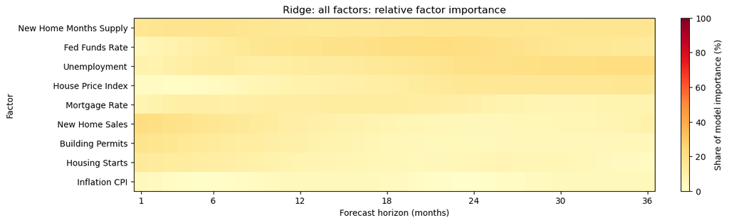

```
Random forest: all factors: average importance across horizons (%)
Inflation CPI             50.2
New Home Months Supply    14.5
Housing Starts            10.5
Building Permits           9.7
Fed Funds Rate             4.4
New Home Sales             4.2
House Price Index          3.7
Unemployment               2.0
Mortgage Rate              0.8
```

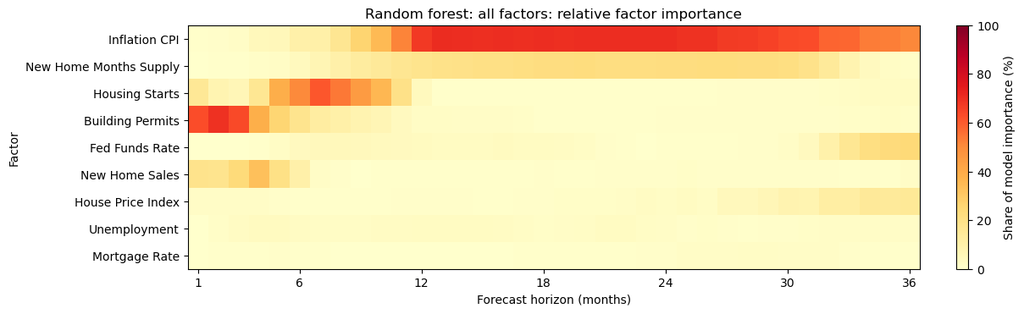

```python
def get_factor_importance(model_name, features):
    fitted_models = models[model_name]
    importance_by_horizon = {}

    for horizon, model in sorted(fitted_models.items()):
        if hasattr(model, "named_steps"):
            # Absolute coefficients for standardized inputs.
            importance = np.abs(model.named_steps["ridge"].coef_)
        else:
            importance = model.feature_importances_

        lag_importance = pd.Series(
            importance,
            index=features.columns,
            dtype=float,
        )

        # Group all selected lags under their original factor.
        factor_names = [
            name.rsplit("_lag_", 1)[0]
            for name in lag_importance.index
        ]

        factor_importance = lag_importance.groupby(
            factor_names, sort=False
        ).sum()

        total = factor_importance.sum()
        if total > 0:
            factor_importance = factor_importance / total * 100

        importance_by_horizon[horizon] = factor_importance

    result = pd.DataFrame(importance_by_horizon)
    result.columns.name = "Forecast horizon (months)"

    order = result.mean(axis=1).sort_values(ascending=False).index
    return result.loc[order]


# Keep feature_sets from the model-building cell.
# The last-value baseline has no fitted feature weights.
factor_importances = {}

for model_name, features in feature_sets.items():
    importance = get_factor_importance(model_name, features)
    factor_importances[model_name] = importance

    print(f"\n{model_name}: average importance across horizons (%)")
    print(importance.mean(axis=1).round(1).to_string())

    fig, ax = plt.subplots(
        figsize=(12, max(3, 0.4 * len(importance))),
        constrained_layout=True,
    )

    heatmap = ax.imshow(
        importance.to_numpy(),
        cmap="YlOrRd",
        aspect="auto",
        vmin=0,
        vmax=100,
    )

    # Find tick positions using the actual fitted horizons.
    tick_horizons = [
        h for h in [1, 6, 12, 18, 24, 30, 36]
        if h in importance.columns
    ]
    ax.set_xticks([
        importance.columns.get_loc(h) for h in tick_horizons
    ])
    ax.set_xticklabels(tick_horizons)

    ax.set_yticks(range(len(importance)))
    ax.set_yticklabels(importance.index)

    ax.set(
        title=f"{model_name}: relative factor importance",
        xlabel="Forecast horizon (months)",
        ylabel="Factor",
    )

    fig.colorbar(
        heatmap,
        ax=ax,
        label="Share of model importance (%)",
    )

    plt.show()
```

The Ridge model distributes importance more evenly across the selected factors. This may reflect overlapping information, although the importance scores alone do not explain its poor forecasting performance.

Interestingly, CPI has the lowest importance in the Ridge model but the highest importance in the random forest. In the forest, housing starts and building permits appear more important at shorter forecast horizons, while CPI becomes more important at longer horizons. These scores indicate model reliance, rather than proven predictive value.

Finally, we evaluate the models using mean absolute error (MAE), root mean squared error (RMSE) and mean absolute percentage error (MAPE), averaged over the test period.

|  | MAE | RMSE | MAPE (%) |
| --- | --- | --- | --- |
| Last-value baseline | 133.50 | 161.02 | 9.24 |
| Ridge: starts only | 134.22 | 164.76 | 8.37 |
| Ridge: all factors | 633.02 | 732.39 | 42.74 |
| Random forest: all factors | 169.52 | 227.56 | 10.76 |
| Ridge: reduced starts only | 144.54 | 173.48 | 9.08 |
| Ridge: starts + permits | 101.31 | 124.51 | 6.44 |
| Ridge: starts + sales | 105.42 | 130.39 | 6.66 |
| Ridge: starts + supply | 98.72 | 115.38 | 6.60 |

```
Evaluated on 36 months.
```

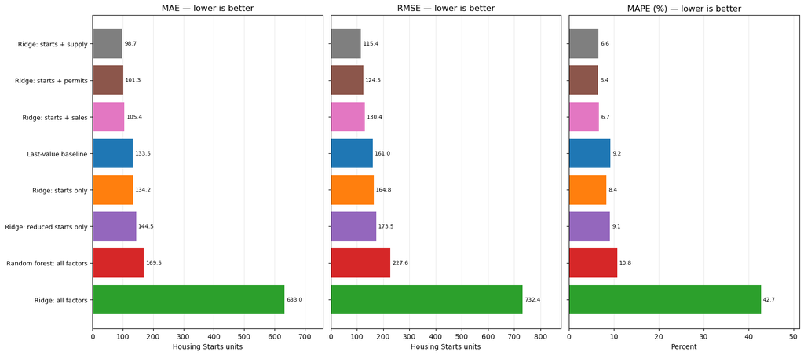

```python
# Evaluate months with actual values and predictions from every model.
observed = actual[TARGET].reindex(predictions.index)
valid = observed.notna() & predictions.notna().all(axis=1)

if not valid.any():
    raise ValueError("No matching months available for evaluation.")

y = observed.loc[valid]
errors = predictions.loc[valid].sub(y, axis=0)

metrics = pd.DataFrame({
    "MAE": errors.abs().mean(),
    "RMSE": np.sqrt(errors.pow(2).mean()),
    "MAPE (%)": errors.abs().div(
        y.abs().replace(0, np.nan), axis=0
    ).mean() * 100,
})

display(metrics.round(2))
print(f"Evaluated on {valid.sum()} months.")

# Match colours to the prediction graph.
palette = plt.get_cmap("tab10")
model_colours = {
    name: palette(number % 10)
    for number, name in enumerate(predictions.columns)
}

# Horizontal bars make eight model names easier to read.
plot_metrics = metrics.sort_values("RMSE")

fig, axes = plt.subplots(
    1, 3,
    figsize=(16, 7),
    constrained_layout=True,
    sharey=True,
)

for ax, metric in zip(axes, plot_metrics.columns):
    bars = ax.barh(
        plot_metrics.index,
        plot_metrics[metric],
        color=[model_colours[name] for name in plot_metrics.index],
    )
    ax.bar_label(bars, fmt="%.1f", padding=3, fontsize=8)

    ax.set(
        title=f"{metric} — lower is better",
        xlabel="Percent" if metric == "MAPE (%)" else "Housing Starts units",
    )
    ax.tick_params(axis="y", labelsize=9)
    ax.set_axisbelow(True)
    ax.grid(axis="x", alpha=0.25)
    ax.margins(x=0.2)

# Best RMSE appears at the top.
axes[0].invert_yaxis()

plt.show()
```

We compare the models using mean absolute error (MAE), root mean squared error (RMSE) and mean absolute percentage error (MAPE). Lower values indicate better forecast accuracy.

## AI Use Statement

All written explanations were originally written by me, and I chose the notebook’s structure. AI tools were used to assist with code generation, brainstorm ideas, and review my writing for spelling, grammar and tone. All code was reviewed and amended by me.